# Economia

Caroline Ferronato

4 de junho de 2017

# O que é Economia

## **O que é**

Ela estuda as formas de comportamento humano resultantes da relação entre as necessidades dos homens e os recursos disponíveis para satisfazê-las. Assim sendo, esta ciência está intimamente ligada à política das nações e à vida das pessoas, sendo que uma das suas principais funções é explicar como funcionam os sistemas econômicos e as relações dos agentes econômicos, propondo soluções para os problemas existentes.

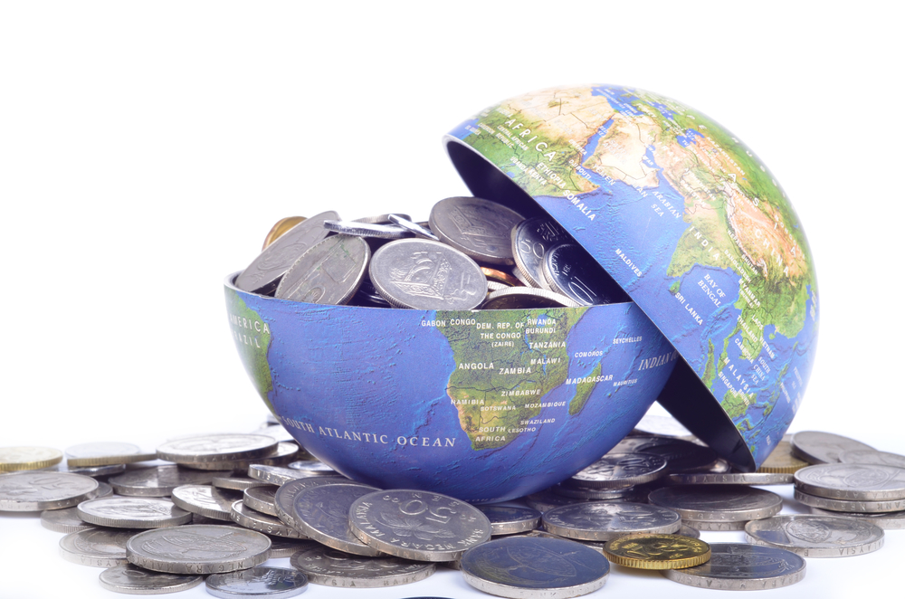

figura 1

## **Divisão no estudo econômico**

- *Macroeconomia*: analisa o comportamento da economia como um todo, por meio de preços e quantidades absolutos. Faz parte dela os movimentos globais nos preços, na produção ou no emprego.
- *Microeconomia*: estuda o comportamento de cada “molécula econômica” do sistema, por meio de preços e quantidades relativas. Para exemplificar, pode-se citar a análise do funcionamento de empresas.

# **Os problemas econômicos fundamentais**

- *O quê e quanto produzir*: dada a escassez de recursos de produção, a sociedade terá de escolher, dentro do leque de possibilidades de produção, quais produtos serão produzidos e as respectivas quantidades a serem fabricadas.
- *Como produzir*: a sociedade terá de escolher ainda quais recursos de produção serão utilizados para a produção de bens e serviços, dado o nível tecnológico existente. A concorrência entre os diferentes produtores acaba decidindo como serão produzidos os bens e serviços. Os produtores escolherão, entre os métodos mais eficientes, aquele que tiver o menor custo de produção possível.
- *Para quem produzir*: a sociedade terá também de decidir como seus membros participarão da distribuição dos resultados de sua produção. A distribuição da renda dependerá não só da oferta e da demanda nos mercados de serviços produtivos, ou seja, da determinação dos salários, das rendas da terra, dos juros e dos benefícios do capital, mas também da repartição inicial da propriedade e da maneira como ela se transmite por herança.